# Ejercicios1

## Parte 2

**1. 1.Graficar los puntos $(1,1),(2,4),(3,6),(4,8),(5,25),(6,36),(7,49),(8,61),(9,81),(10,100)$ en un plano utilizando RStudio.**

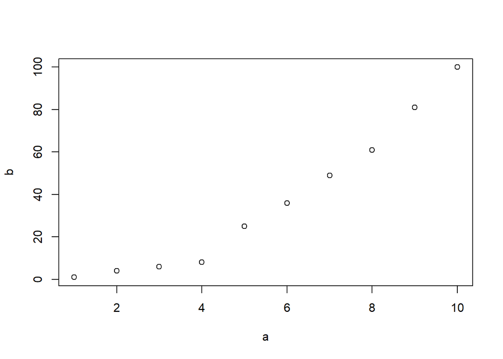

```r
a <- c(1:10)
b <- c(1,4,6,8,25,36,49,61,81,100)
plot(x= a, y = b)
```

**2. Ingresar la matriz A en RStudio** $A = \begin{pmatrix} 1 & 2 & 3 \\ 2 & 4 & 6 \\ 3 & 6 & 9 \\ 4 & 8 & 12 \end{pmatrix}$

```r
a <- c(1:4)
b <- c(a*2)
c <- c(a*3)


matrix <- cbind(a,b,c) # rbind o juntar por columnas
A <- matrix
A
```

```
##      a b  c
## [1,] 1 2  3
## [2,] 2 4  6
## [3,] 3 6  9
## [4,] 4 8 12
```

**3. Ingresar la matriz identidad de tamaño 3** $I = \begin{pmatrix} 1 & 0 & 0 \\ 0 & 1 & 0 \\ 0 & 0 & 1 \end{pmatrix}$

```r
d <- diag(1,3,3) #en la diagonal "1" y matriz 3*3
d
```

```
##      [,1] [,2] [,3]
## [1,]    1    0    0
## [2,]    0    1    0
## [3,]    0    0    1
```

```r
3*d
```

```
##      [,1] [,2] [,3]
## [1,]    3    0    0
## [2,]    0    3    0
## [3,]    0    0    3
```

**4. Crea una función que cree una matriz nula ingresando las dimensiones**

```r
d <- diag(0,4,4)
d
```

```
##      [,1] [,2] [,3] [,4]
## [1,]    0    0    0    0
## [2,]    0    0    0    0
## [3,]    0    0    0    0
## [4,]    0    0    0    0
```

**5. Modificar la matriz `diag(4)`, para que se parezca a la matriz B** $B = \begin{pmatrix} 0 & 0 & 0 & 0 \\ 0 & 2 & 0 & 0 \\ 0 & 0 & 3 & 0 \\ 0 & 0 & 0 & 4 \end{pmatrix}$

```r
B<-d
B[1,1]=0
B[2,2]=2
B[3,3]=3
B[4,4]=4
B
```

```
##      [,1] [,2] [,3] [,4]
## [1,]    0    0    0    0
## [2,]    0    2    0    0
## [3,]    0    0    3    0
## [4,]    0    0    0    4
```

**6. Obtener la matriz transpuesta de A (ejercicio 2)**

```r
t(A)
```

```
##   [,1] [,2] [,3] [,4]
## a    1    2    3    4
## b    2    4    6    8
## c    3    6    9   12
```

**7. Realizar las siguientes operaciones $A + B$, $A - B$, $3B$ y $AB$**

```r
#A+B  #dimensiones incompatibles
#A-B  #dimensiones incompatibles
3*B
```

```
##      [,1] [,2] [,3] [,4]
## [1,]    0    0    0    0
## [2,]    0    6    0    0
## [3,]    0    0    9    0
## [4,]    0    0    0   12
```

```r
#A%*%B  #dimensiones incompatibles
```

**8. Crea una función para calcular $P^6$** $P = \begin{pmatrix} 1 & 2 & 3 \\ -2 & 4 & -2 \\ 1 & 0 & 1 \end{pmatrix}$

```r
P <- matrix(c(1,-2,1,2,4,0,3,-2,1), nrow=3, ncol=3)
  # %*% este es el multiplicador de matrices

potencia <- function(X,n){M=X;
for (i in 2:n){M=M%*%X};
print(M)}

potencia(P,6)
```

```
##       [,1]  [,2]  [,3]
## [1,] -1792    24 -2824
## [2,]  -464 -2416 -1344
## [3,]  -648   440  -912
```

**9. Resolver el sistema de ecuaciones** $3x - y + z = -1\\9x - 2y + z = -9\\3x + y - 2z = -9$

```r
A =matrix(c(3,9,3,-1,-2,1,1,1,-2), ncol=3,nrow=3)
A
```

```
##      [,1] [,2] [,3]
## [1,]    3   -1    1
## [2,]    9   -2    1
## [3,]    3    1   -2
```

```r
L <-c(-1,-9,-9)
solve(A,L)
```

```
## [1] -1  2  4
```

**10. Utilizando la ayuda de R, investigue para qué sirven las funciones `eigen()` y `det()`**

```r
eigen(A)
```

```
## eigen() decomposition
## $values
## [1]  1.732051 -1.732051 -1.000000
##
## $vectors
##           [,1]        [,2]          [,3]
## [1,] 0.2955268 -0.08260515  5.441136e-16
## [2,] 0.8363784  0.48159851 -7.071068e-01
## [3,] 0.4616655  0.87249027 -7.071068e-01
```

```r
det(A)
```

```
## [1] 3
```

**11. Considerando las matrices**

B=
$$\begin{pmatrix}
1 & 2 & 3 & 4 & 5 \\
2 & 4 & 6 & 8 & 10 \\
3 & 6 & 9 & 12 & 15 \\
4 & 8 & 12 & 16 & 20 \\
5 & 10 & 15 & 20 & 25 \\
6 & 12 & 18 & 24 & 30 \\
7 & 14 & 21 & 28 & 35 \\
8 & 16 & 24 & 32 & 40 \\
9 & 18 & 27 & 36 & 45 \\
10 & 20 & 30 & 40 & 50
\end{pmatrix}$$
A =
$$\begin{pmatrix}
0 & 1 & 0 & 1 & 0 \\
1 & 0 & 1 & 0 & 1 \\
0 & 1 & 0 & 1 & 0 \\
0 & 1 & 0 & 0 & 1 \\
1 & 0 & 1 & 1 & 0 \\
\end{pmatrix}$$

Calcular $A \cdot B - A B^t$

```r
b <- c(1:10)
c <- c(b*2)
d <- c(b*3)
e <- c(b*4)
f <- c(b*5)

B <- cbind(b,c,d,e,f)
B
```

```
##        b  c  d  e  f
##  [1,]  1  2  3  4  5
##  [2,]  2  4  6  8 10
##  [3,]  3  6  9 12 15
##  [4,]  4  8 12 16 20
##  [5,]  5 10 15 20 25
##  [6,]  6 12 18 24 30
##  [7,]  7 14 21 28 35
##  [8,]  8 16 24 32 40
##  [9,]  9 18 27 36 45
## [10,] 10 20 30 40 50
```

```r
x <- c(0,1)
x1 <- rep(x,7)


y <- c(0,0,1)
y1 <- rep(y,2)

z <- c(1,0,1,1,0)

A <- matrix(c(x1,y1,z), nrow =5, ncol =5, by=TRUE)
A
```

```
##      [,1] [,2] [,3] [,4] [,5]
## [1,]    0    1    0    1    0
## [2,]    1    0    1    0    1
## [3,]    0    1    0    1    0
## [4,]    0    1    0    0    1
## [5,]    1    0    1    1    0
```

```r
#A%*%B #no cumple
primero <-B%*%A
primero
```

```
##       [,1] [,2] [,3] [,4] [,5]
##  [1,]    7    8    7    9    6
##  [2,]   14   16   14   18   12
##  [3,]   21   24   21   27   18
##  [4,]   28   32   28   36   24
##  [5,]   35   40   35   45   30
##  [6,]   42   48   42   54   36
##  [7,]   49   56   49   63   42
##  [8,]   56   64   56   72   48
##  [9,]   63   72   63   81   54
## [10,]   70   80   70   90   60
```

```r
trans <- t(B)
segundo <- A%*%trans
segundo
```

```
##      [,1] [,2] [,3] [,4] [,5] [,6] [,7] [,8] [,9] [,10]
## [1,]    6   12   18   24   30   36   42   48   54    60
## [2,]    9   18   27   36   45   54   63   72   81    90
## [3,]    6   12   18   24   30   36   42   48   54    60
## [4,]    7   14   21   28   35   42   49   56   63    70
## [5,]    8   16   24   32   40   48   56   64   72    80
```

```r
#primero-segundo  #no sale
```

**12. Considere** $\hat\beta = (X^t \cdot X)^{-1} \cdot X^t \cdot Y$

Determine la matriz $\hat\beta$

x=
$$\begin{pmatrix}1 & 1\\ 1 & -1\\ 1 & 0\\ 1 & 1\\ 1 & 2\\ \end{pmatrix}$$
y =
$$\begin{pmatrix}0\\0\\1\\1\\3\\\end{pmatrix}$$

```r
a <- rep(1,5)
a
```

```
## [1] 1 1 1 1 1
```

```r
b <- c(1,-1,0,1,2)

x <- cbind(a,b)
x
```

```
##      a  b
## [1,] 1  1
## [2,] 1 -1
## [3,] 1  0
## [4,] 1  1
## [5,] 1  2
```

```r
y <- rbind(0,0,1,1,3)
y
```

```
##      [,1]
## [1,]    0
## [2,]    0
## [3,]    1
## [4,]    1
## [5,]    3
```

```r
m <- t(x)
n <- m%*%x
s <- solve(n)
t <- s%*%m
u <- t%*%y
u
```

```
##        [,1]
## a 0.5384615
## b 0.7692308
```

```r
#t(x)%*%x %>% solve() %*% t(x) %*% y
```

**13. Corre el siguiente código para cargar los vectores `year` y `co2`** en memoria

```r
data(co2)
means = aggregate(co2, FUN=mean)
year = as.vector(time(means))
co2 = as.vector(means)
```

**14.**